# Estimating density-dependent survival with OPSCR models and nimbleSCR

Cyril Milleret, Soumen Dey, Pierre Dupont, Richard Bischof

2022-10-28

In this vignette, we demonstrate how to use the nimbleSCR (Bischof et al. 2020) and NIMBLE packages (de Valpine et al. 2017; NIMBLE Development Team 2020) to simulate open-population spatial capture-recapture (OPSCR) data and fit flexible and efficient Bayesian OPSCR models with spatially explicit mortality assumed to be a function of density. We assume that we have access to detections of alive individuals. The demographic model is parameterized using a hazard rate formulation. See details in Milleret et al 2022 Estimating spatially variable and density-dependent survival using open-population spatial capture-recapture models; Ecology

```r
## Load packages
library(nimble)
library(nimbleSCR)
library(basicMCMCplots)
library(raster)
library(coda)
```

## 1. Simulate SCR data

### 1.1 Habitat and trapping grid

As an example, we create a $36 \times 36$ habitat grid with a resolution of 4 distance units (du) along each dimension. On the habitat, we center a $28 \times 28$ trapping grid with a resolution of 1 du along each dimension.

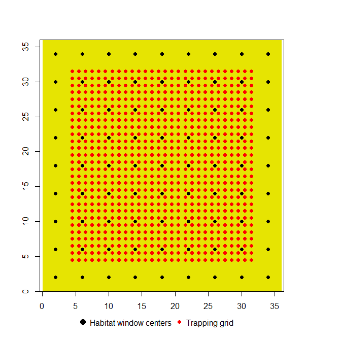

```r
r <- raster(nrows=9, ncols=9, xmn=0, xmx=36, ymn=0, ymx=36)
r[] <- 1
## Create habitat grid
coordsHabitatGridCenter <- coordinates(r)
colnames(coordsHabitatGridCenter) <- c("x","y")

## Create trapping grid
coordsObsCenter <- cbind(rep(seq(4.5, 31.5, by = 1), 28),
                         sort(rep(seq(31.5, 4.5, by = -1), 28)))
colnames(coordsObsCenter) <- c("x","y")

## Plot check
plot(r,legend=F)
points(coordsHabitatGridCenter[,"y"] ~ coordsHabitatGridCenter[,"x"],
     pch = 16, cex = 1)
points(coordsObsCenter[,"y"] ~ coordsObsCenter[,"x"], col="red", pch=16 )
par(xpd=TRUE)
legend(x = 5, y = -3,
       legend=c("Habitat window centers", "Trapping grid"),
       pt.cex = c(1.5,1),
       horiz = T,
       pch=c(16,16),
       col=c("black", "red"),
       bty = 'n')
```

```r
habitatMask <- as.matrix(r)
```

### 1.2 Rescale coordinates

To implement the local evaluation approach when fitting the SCR model (see Milleret et al. (2019) and Turek et al. (2021) for further details), we need to rescale the habitat and trapping grid coordinates so that each habitat cell is of dimension $1 \times 1$. We also need to identify the lower and upper coordinates of each habitat cell using the ‘getWindowCoords’ function.

```r
## Rescale coordinates
scaledObjects <- scaleCoordsToHabitatGrid(
  coordsData = coordsObsCenter,
  coordsHabitatGridCenter = coordsHabitatGridCenter)

## Get lower and upper cell coordinates
lowerAndUpperCoords <- getWindowCoords(
  scaledHabGridCenter = scaledObjects$coordsHabitatGridCenterScaled,
  scaledObsGridCenter = scaledObjects$coordsDataScaled,
  plot.check = F)
```

Next, we set up the objects necessary to perform the local evaluation for the live detection using the ‘getLocalObjects’ function. Special care should be taken when chosing ‘dmax’ relative to $\sigma$ (Milleret et al. 2019). Here we use a value $>3*\sigma$ (see below for the $\sigma$ chosen).

```r
trapLocal <- getLocalObjects(habitatMask = habitatMask,
                             coords = scaledObjects$coordsDataScaled,
                             dmax = 1.8,
                             resizeFactor = 1,
                             plot.check = F
)
```

### 1.3 Define model code

In this example, we build an OPSCR model assuming a Markovian and bivariate distribution of the movement of individual activity centers across occasions. We use a multi-state demographic submodel where each individual life history is represented by a succession (implemented with custom distribution `dcatState1Alive1Dead`) of up to three discrete state $z_{i,t}$: 1) ‘unborn’ if the individual has not been recruited in the population; 2) ‘alive’ if it is alive; 3)‘dead’ if it is dead. We assumed mortality (transition from state 2 to 3) is a function of density. Full details are available in Milleret et al. 2022. Estimating spatially variable and density-dependent survival using open-population spatial capture-recapture models; Ecology.

```r
modelCode <- nimbleCode({
  ##--------------------------------------------------------------------------------------------
  ##-----------------------------##
  ##------ SPATIAL PROCESS ------##
  ##-----------------------------##
  tau ~ dgamma(0.001, 0.001)
  logHabIntensity[1:numHabWindows] <- mu[1:numHabWindows]
  sumHabInt <- log(sum(mu[1:numHabWindows]))
  ## FIRST YEAR
  for(i in 1:M){
    s[i, 1:2,1] ~ dbernppAC(
      lowerCoords = lowerHabCoords[1:numHabWindows, 1:2],
      upperCoords = upperHabCoords[1:numHabWindows, 1:2],
      logIntensities = logHabIntensity[1:numHabWindows],
      logSumIntensity = sumHabInt,
      habitatGrid = habitatGrid[1:y.max,1:x.max],
      numGridRows =  y.max,
      numGridCols = x.max
    )
  }#i

  ## T>1
  for(t in 2:n.years){
    for(i in 1:M){
      s[i, 1:2, t] ~ dbernppACmovement_normal(lowerCoords = lowerHabCoords[1:numHabWindows, 1:2]
                                                , upperCoords = upperHabCoords[1:numHabWindows, 1:2]
                                                , s = s[i, 1:2, t - 1]
                                                , sd = tau
                                                , baseIntensities = mu[1:numHabWindows]
                                                , habitatGrid =  habitatGrid[1:y.max,1:x.max]
                                                , numGridRows = y.max
                                                , numGridCols = x.max
                                                , numWindows= numHabWindows
      )
    }#i
  }#t

  ##--------------------------------------------------------------------------------------------
  ##-------------------------------##
  ##----- DEMOGRAPHIC PROCESS -----##
  ##-------------------------------##
  ##INTERCEPT MORTALITY HR
  ## FIRST YEAR INCLUSION PARAMETER
  gamma1 ~ dunif(0,1)
  omeg1[1:2] <- c(1-gamma1, gamma1)

  ## TIME SPECIFIC INCLUSION PARAMETER
  for(t in 1:n.years1){
    gamma[t] ~ dunif(0,1)
  }#t


  ## SPATIAL (DENSITY DEPENDENT) SURVIVAL
  betaPhi ~ dunif(-10,10)
  phi0 ~ dunif(-10,10)

    ## DERIVE SURVIVAL PROBABILITY
  for(t in 1:n.years1){
      phi[1:n.cells,t] <-  1-(exp(-exp(phi0 +  log(dens[1:n.cells, t]+1) * betaPhi)))
  }


  for(i in 1:M){
    z[i,1] ~ dcat(omeg1[1:2])
    for(t in 1:n.years1){
      z[i,t+1] ~ dcatState1Alive1Dead( z = z[i,t]
                                 , prob1To2 = gamma[t]
                                 , prob2To3Hab = 1-phi[1:numHabWindows,t]
                                 , s = s[i,1:2,t]
                                 , habitatGrid = habitatGrid[1:y.max,1:x.max]
      )

    }#i
  }#t

  ##---------------------------------------------------------------------------------------------
  ##-----------------------------##
  ##----- DETECTION PROCESS -----##
  ##-----------------------------##
  sigma ~ dunif(0,15)
  p0 ~ dunif(0,1)

  for(t in 1:n.years){
    for (i in 1:M){

      # ALIVE
       y[i, 1:lengthYCombined,t] ~ dbinomLocal_normal(size = trials[1:n.traps],
                                                 p0 = p0,
                                                 s = s[i,1:2,t],
                                                 sigma = sigma,
                                                 trapCoords = trapCoords[1:n.traps,1:2],
                                                 localTrapsIndices = trapIndex[1:n.cells,1:maxNBDets],
                                                 localTrapsNum = nTraps[1:n.cells],
                                                 resizeFactor = resizeFactor,
                                                 habitatGrid = habitatIDDet[1:y.maxDet,1:x.maxDet],
                                                 indicator = isAlive[i,t],
                                                 lengthYCombined = lengthYCombined)


    }#i
  }#t

  ##---------------------------------------------------------------------------------------------
  ##----------------------------------------##
  ##---------- DERIVED PARAMETERS ----------##
  ##----------------------------------------##
  for(i in 1:M){
    isAlive[i,1] <- (z[i,1] == 2)
    for(t in 1:n.years1){
      isAlive[i,t+1] <- (z[i,t+1] == 2)
    }
  }

  for(t in 1:n.years){
    N[t] <- sum(isAlive[1:M,t])
  }#t

  # CALCULATE DENSITY
  for (t in 1:n.years) {
    dens[1:n.cells, t] <- calculateDensity(  s = s[1:M,1:2, t]
                                           , habitatGrid = habitatGrid[1:y.maxDet, 1:x.maxDet]
                                           , indicator = isAlive[1:M,t]
                                           , numWindows = n.cells
                                           , nIndividuals = M)#6
  }

})
```

### 1.4 Define parameter values to simulate

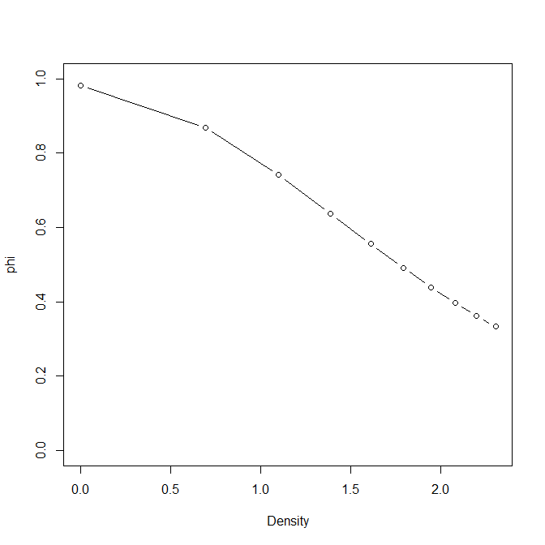

```r
# PARAMETERS
p0 <- 0.15 # We intentionally chose a large p0 to increase the size of the dataset and obtain better convergence
sigma <- 2/res(r)[1] # Since we scaled the coordinates to the habitat, we also need to rescale sigma

M <- 650
n.individualsT1 <- 250
n.years <- 5
## ASSIGN SIMULATED VALUES
phi0 <- 1.4

betaPhi <- -1
tau <- 1.5

recruitment <- 0.3
## CALCULATE GAMMA
gamma <- n.individualsT1/M
Recruit <- n.individualsT1*recruitment ## 40 % of recruitment
NeverAlive <- n.individualsT1

for(t in 2:n.years){
    Navai  <- M- NeverAlive[t-1]
    gamma[t] <- Recruit/Navai
    NeverAlive[t] <- NeverAlive[t-1] + Recruit
}


lengthYCombined <- 1 + trapLocal$numLocalIndicesMax*2


## EXPECTED SURVIVAL PROBABILITY AS A FUNCTION OF DENSITY
dens <- log(c(1:10))
phi <- 1-(exp(- exp(phi0 +  dens * betaPhi)))
plot(phi ~ dens, ylim=c(0,1), type="b", xlab="Density")
```

### 1.5 Create constants, data, and inits objects

```r
nimConstants <- list(M = M,
                     n.years = n.years,
                     n.years1 = n.years-1,
                     n.traps = dim(scaledObjects$coordsDataScaled)[1],
                     y.max = dim(habitatMask)[1],
                     x.max = dim(habitatMask)[2],
                     y.maxDet = dim(trapLocal$habitatGrid)[1],
                     x.maxDet = dim(trapLocal$habitatGrid)[2],
                     resizeFactor = trapLocal$resizeFactor,
                     n.cells = dim(trapLocal$localIndices)[1],
                     maxNBDets = trapLocal$numLocalIndicesMax,
                     trapIndex = trapLocal$localIndices,
                     nTraps = trapLocal$numLocalIndices,
                     habitatIDDet = trapLocal$habitatGrid,
                     lengthYCombined = lengthYCombined,
                     numHabWindows = dim(lowerAndUpperCoords$lowerHabCoords)[1])

nimData <- list(trapCoords = scaledObjects$coordsDataScaled,
                trials = rep(1, dim(scaledObjects$coordsDataScaled)[1]),
                lowerHabCoords = lowerAndUpperCoords$lowerHabCoords,
                upperHabCoords = lowerAndUpperCoords$upperHabCoords,
                habitatGrid = lowerAndUpperCoords$habitatGrid,
                mu = rep(1, dim(lowerAndUpperCoords$lowerHabCoords)[1])
                )

# We set the parameter values as inits
nimInits <- list(sigma = sigma,
                 p0 = p0,
                 tau = tau,
                 gamma = gamma[2:n.years],
                 gamma1 = gamma[1],
                 betaPhi = betaPhi,
                 phi0 = phi0)
```

### 1.6 Create NIMBLE model

```r
model <- nimbleModel( code = modelCode,
                      constants = nimConstants,
                      data = nimData,
                      inits = nimInits,
                      check = F,
                      calculate = F)
```

### 1.7 Simulate SCR data from the NIMBLE model

Using NIMBLE function ‘getDependencies’, we obtain the list of nodes to be be simulated. Using the ‘simulate’ function from NIMBLE, we then simulate the activity center (AC) locations (‘s’), the state of the individual (‘z’) and SCR observation data (‘y’).

```r
# FIRST WE GET THE NODES TO SIMULATE
nodesToSim <- model$getDependencies(c("p0","sigma","phi0", "betaPhi","mu",
                                      "gamma","tau","gamma1"),
                                      self = F,
                                      downstream = T,
                                      returnScalarComponents = TRUE)
# THEN WE SIMULATE THOSE NODES
set.seed(100)
model$simulate(nodesToSim, includeData = FALSE)
```

After running ‘simulate’, the simulated data are stored in the ‘model’ object. For example, we can access the simulated ‘z’ and check how many individuals were considered alive and recovered at each time step:

```r
N <- apply(model$z,2,function(x)sum(x==2))
N
```

```
## [1] 262 230 210 217 205
```

```r
N.recoveredDead <- apply(model$z,2,function(x)sum(x==3))
N.recoveredDead
```

```
## [1]   0 114 202 262 351
```

```r
# check average density
mean(log(model$dens+1))
```

```
## [1] 1.210626
```

## 2. RUN MCMC WITH NIMBLE

Here, we build the NIMBLE model again using the simulated ‘y’ as data. For simplicity, we use the simulated ‘z’ as initial values. Then we can fit the OPSCR model with the simulated ‘y’ data set.

```r
myZ <- model$z
z <- zInits <- model$z
whichDet <- apply(model$y, 3, function(x) x[,1]>0 )
whichNotDet <- apply(model$y, 3, function(x) x[,1]==0 )

z[whichNotDet] <- NA
zInits[whichDet] <- NA

nimData$y <- model$y

nimData$z <- z
nimInits$z <- zInits
nimInits$s <- model$s

# CREATE AND COMPILE THE NIMBLE MODEL
model <- nimbleModel( code = modelCode,
                      constants = nimConstants,
                      data = nimData,
                      inits = nimInits,
                      check = F,
                      calculate = F)
model$calculate()
```

```
## [1] -22673.57
```

```r
cmodel <- compileNimble(model)
cmodel$calculate()
MCMCconf <- configureMCMC(model = model,
                          monitors = c("p0","sigma","betaPhi","phi0", "N","dens",
                                         "gamma","tau"),
                          control = list(reflective = TRUE),
                          thin = 1)

###FIND WHICH Z NODES NEED TO BE REPLACED BY THE NEW SAMPLER.
samplerConfList <- unlist(lapply(MCMCconf$getSamplers(),function(x) x$target))
zNodes <- samplerConfList[grep("z",samplerConfList)]
## FIND Z NODES FROM THE FIRST YEAR (SHOULD NOT BE REPLACED)
zNodes <- zNodes[-grep( ", 1]",zNodes)]

MCMCconf
#remove samplers
MCMCconf$removeSamplers(zNodes)
MCMCconf$addSampler(target = zNodes,
                      type = 'sampler_categorical_general',
                      scalarComponents = TRUE,
                      control = list("numCategories"= 3))

MCMC <- buildMCMC(MCMCconf)
cMCMC <- compileNimble(MCMC, project = model, resetFunctions = TRUE)
# RUN THE MCMC
MCMCRuntime <- system.time(myNimbleOutput <- runMCMC( mcmc = cMCMC,
                                                             nburnin = 500,
                                                             niter = 5000,# need much longer run time (60000)
                                                             nchains = 2,
                                                             samplesAsCodaMCMC = TRUE))
```

## 3. PLOT POSTERIORS

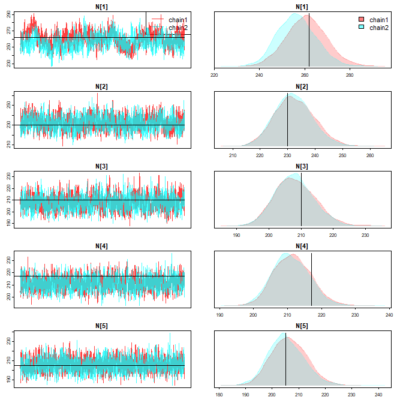

```r
#plot MCMC
chainsPlot(myNimbleOutput, var=c("N[1]","N[2]","N[3]","N[4]","N[5]"), line=N)
```

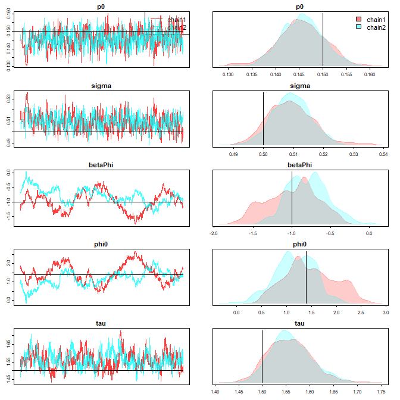

```r
chainsPlot(myNimbleOutput, var=c("p0","sigma","betaPhi","phi0","tau"), line=c(p0, sigma, betaPhi, phi0, tau))
```

## 3. IMPROVE MIXING BY CENTERING DENSITY

In an OPSCR model with density-dependent survival, the log-density is used as a covariate for determining location and time-specific survival rates. As expected for such model structures, use of this covariate induces a strong negative correlation between the posterior samples of the intercept and slope of the linear predictor ($phi_0$ and $\beta_{\phi}$, respectively). This particular model is complicated further by the fact that density itself is a non-constant latent variable, making it more difficult to address this posterior correlation and resulting in slow mixing. Here, we demonstrate that by centering the density (‘dens’), that is, try to make log(density+1) have a mean of 0, we can reduce the correlation between ‘betaPhi’ and ‘phi0’ and improve the mixing. We can’t do this exactly, because density is time- and location-dependent, but we can strive for 0-mean on average. From a preliminary run (in our case the one above), we can note the average of log(density+1) over time and space. For the specific data set simulated in this vignette, mean(log(density)+1) = 1.2.

Now we can modify the model to center density:

```r
for(t in 1:n.years1){
  phi[1:n.cells,t] <-  1- (exp(- exp(phi0 + (log(dens[1:n.cells, t]+1) - dens_offset) * betaPhi)))
}
```

Where the variable “dens_offset” can be provided as a *constant value* in the nimConstants list.

```r
mean(log(myNimbleOutput[[2]][,grep("dens", colnames(myNimbleOutput[[1]]))]+1))
```

```
## [1] 1.20669
```

```r
nimConstants$dens_offset <- 1.2
```

Now we can rewrite the model to center the density (‘dens’) by replacing the following line in the model code

```r
 phi[1:n.cells,t] <-  1-(exp(-exp(phi0 +  log(dens[1:n.cells, t]+1) * betaPhi)))
```

with

```r
 phi[1:n.cells,t] <-  1- (exp(- exp(phi0 + (log(dens[1:n.cells, t]+1) - dens_offset) * betaPhi)))
```

We now build and fit the model with centered density following the same procedure as shown above:

```r
nimInits$phi0 <- -3 ## we modify the initial value.

model1 <- nimbleModel( code = modelCode1,
                      constants = nimConstants,
                      data = nimData,
                      inits = nimInits,
                      check = F,
                      calculate = F)
model1$calculate()
cmodel1 <- compileNimble(model1)
cmodel1$calculate()
MCMCconf1 <- configureMCMC(model = model1,
                          monitors = c("p0","sigma","betaPhi","phi0", "N","dens",
                                         "gamma","tau"),
                          control = list(reflective = TRUE),
                          thin = 1)

###FIND WHICH Z NODES NEED TO BE REPLACED BY THE NEW SAMPLER.
samplerConfList <- unlist(lapply(MCMCconf1$getSamplers(),function(x) x$target))
zNodes <- samplerConfList[grep("z",samplerConfList)]
#find z nodes from the first year
zNodes <- zNodes[-grep( ", 1]",zNodes)]

MCMCconf1
#remove samplers
MCMCconf1$removeSamplers(zNodes)
MCMCconf1$addSampler(target = zNodes,
                      type = 'sampler_categorical_general',
                      scalarComponents = TRUE,
                      control = list("numCategories"= 3))


MCMC1 <- buildMCMC(MCMCconf1)
cMCMC1 <- compileNimble(MCMC1, project = model1, resetFunctions = TRUE)
# RUN THE MCMC
MCMCRuntime1 <- system.time(myNimbleOutput1 <- runMCMC( mcmc = cMCMC1,
                                                             nburnin = 500,
                                                             niter = 5000,# need much longer run time (60000)
                                                             nchains = 2,
                                                             samplesAsCodaMCMC = TRUE))
```

## 3. PLOT POSTERIORS

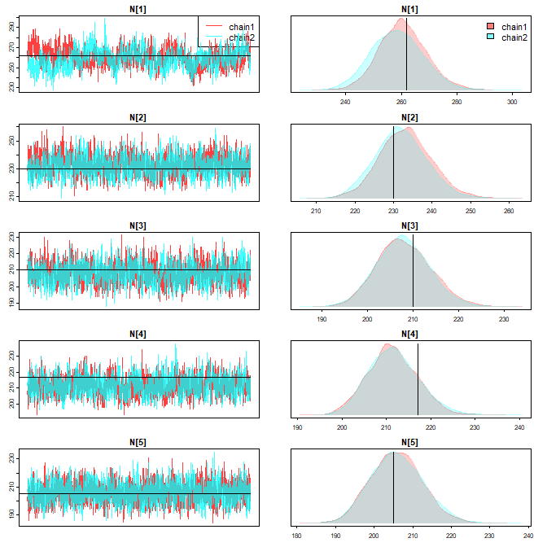

```r
#plot MCMC
chainsPlot(myNimbleOutput1, var=c("N[1]","N[2]","N[3]","N[4]","N[5]"), line=N)
```

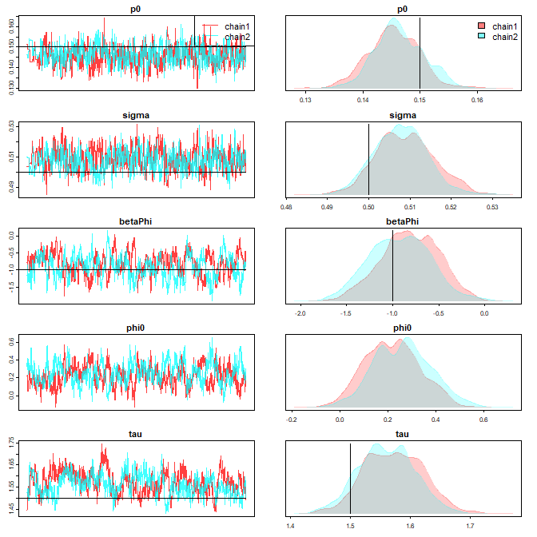

```r
chainsPlot(myNimbleOutput1, var=c("p0","sigma","betaPhi","phi0","tau"), line=c(p0, sigma,betaPhi,phi0, tau))
```

We can compare the effective sample size of the the model without and without the density.

```r
effectiveSize(myNimbleOutput1)[c("phi0","betaPhi")]
```

```
##     phi0  betaPhi
## 113.0539 114.7456
```

```r
effectiveSize(myNimbleOutput)[c("phi0","betaPhi")]
```

```
##     phi0  betaPhi
## 11.97863 12.22744
```

The correlation between phi0 and betaPhi also decreased.

```r
cor(myNimbleOutput1[[1]][,c("betaPhi")], myNimbleOutput1[[1]][,c("phi0")])
```

```
## [1] -0.8850137
```

```r
cor(myNimbleOutput[[1]][,c("betaPhi")], myNimbleOutput[[1]][,c("phi0")])
```

```
## [1] -0.9937947
```

## REFERENCES

Bischof, Richard, Daniel Turek, Cyril Milleret, Torbjorn Ergon, Pierre Dupont, and Perry de Valpine. 2020. *nimbleSCR: Spatial Capture-Recapture (SCR) Methods Using ’Nimble’*.

de Valpine, Perry, Daniel Turek, Christopher J Paciorek, Clifford Anderson-Bergman, Duncan Temple Lang, and Rastislav Bodik. 2017. “Programming with Models: Writing Statistical Algorithms for General Model Structures with NIMBLE.” *J. Comput. Graph. Stat.* 26 (2): 403–13.

Milleret, Cyril, Pierre Dupont, Christophe Bonenfant, Henrik Brøseth, Øystein Flagstad, Chris Sutherland, and Richard Bischof. 2019. “A Local Evaluation of the Individual State-Space to Scale up Bayesian Spatial Capture–Recapture.” *Ecology and Evolution* 9 (1): 352–63. https://doi.org/10.1002/ece3.4751.

NIMBLE Development Team. 2020. “NIMBLE: MCMC, Particle Filtering, and Programmable Hierarchical Modeling.” https://doi.org/10.5281/zenodo.1211190.

Turek, Daniel, Cyril Milleret, Torbjørn Ergon, Henrik Brøseth, Pierre Dupont, Richard Bischof, and Perry de Valpine. 2021. “Efficient Estimation of Large-Scale Spatial Capture–Recapture Models.” *Ecosphere* 12 (2): e03385. https://doi.org/https://doi.org/10.1002/ecs2.3385.